# P. pyralis adult infection survival: testing statistical assumptions

Moria Chambers + Sarah Lower

2022-09-21

# Goal: Test whether covariates fulfill assumption of CoxPH analysis (linear relationship with survival)

*Study design:*

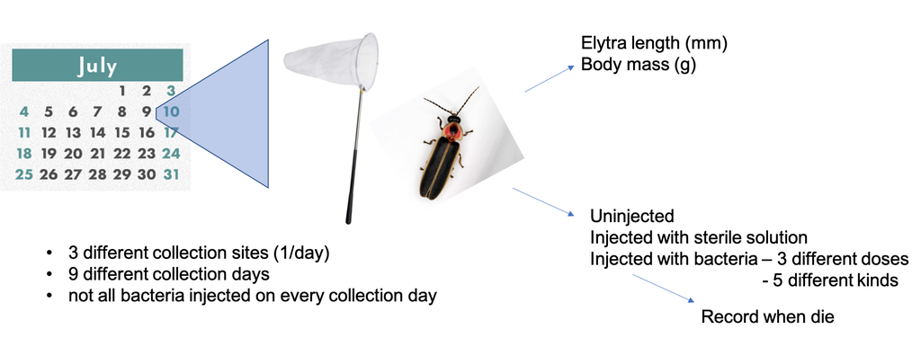

- Covariates examined for basic biological trends (e.g. does condition decrease over season, are there differences in condition by location)
  - Condition
  - Season day
  - Location
- Covariates tested for linear relationship with survival:
  - Condition
  - Season day

## Step 1: Ready the workspace

```r
#clear all inputs
rm(list = ls())

#Check for necessary packages
list.of.packages <- c("survival",
                      "survminer",
                      "ggplot2",
                      "tidyr",
                      "dplyr",
                      "Hmisc",
                      "qqplotr",
                      "ggthemes",
                      "fabricatr",
                      "gridExtra",
                      "grid",
                      "kableExtra",
                      "sjPlot",
                      "cowplot",
                      "ggpubr",
                      "patchwork",
                      "magick", #so you can use the savekable function
                      "webshot", #so you can use the savekable function
                      "lme4",
                      "RcppEigen")

#should install packages that you don't have
new.packages <- list.of.packages[!(list.of.packages %in% installed.packages()[,"Package"])]
if(length(new.packages)) install.packages(new.packages)

#Load the package that contains the Cox Propotional Hazard Function
library(survival)
library(ggplot2)
library(tidyr)
library(dplyr)
library(Hmisc)
library(qqplotr)
library(ggthemes)
library(fabricatr)
library(survminer)
library(gridExtra)
library(grid)
library(kableExtra)
library(sjPlot)
library(cowplot)
library(ggpubr)
library(patchwork)
```

## Step 2: Import the data and create **Condition** variable

```r
#This imports the data from a CSV file and creates the data frame PrTC
Adult_Final<-read.table("2021_Adult_Firefly_Survival_binned3.csv", header=TRUE, sep=",", dec=".",na.strings=".")

#Code to explore linearity of survival data using binned covariates:
#add Condition variable
Adult_Final$Condition <- Adult_Final$Mass/Adult_Final$ElytralLength

#Subset the data to only include uninfected controls
Adult_Uninfected<-subset(Adult_Final, DoseBacteriaNumber=="0")
#nrow(Adult_Uninfected)

#This sets up the color palette using tableau20: https://jrnold.github.io/ggthemes/reference/tableau_color_pal.html
site_colors <- c("USA: Montour Co, Bucknell Natural Area" = "#4E79A7",
                 "USA: Union Co, Bucknell Farm" = "#F28E2B",
                 "USA: Union Co, Bucknell Ropes Course" = "#E15759")
```

## Step 3: Visualizing variation in **Condition**

### Q1. What does the condition distribution look like overall?

- **Raw data**

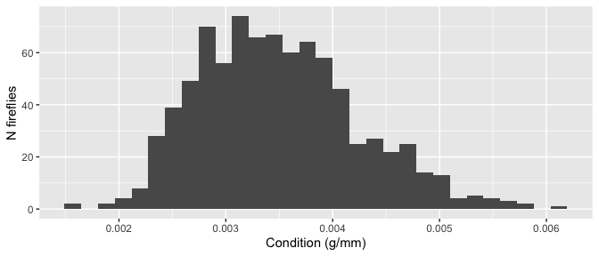

```r
#generate distribution of raw data
z <- ggplot(Adult_Final, aes(x=Condition)) +
  geom_histogram() +
  xlab("Condition (g/mm)") +
  ylab("N fireflies") +
  theme(plot.title = element_text(hjust = 0.5))
z
```

### Q2. …by location?

- Data summary:

```r
#generate tibble
t<- Adult_Final %>%
  group_by(Location) %>%
  summarise(N=n(), mean_length=round(mean(Condition),6), SD = round(sd(Condition), 6))

#generate nice looking table
kbl(t, col.names = c("Location", "n", "Mean condition (g/mm)", "SD"), align = "lccc") %>%
  kable_classic(full_width = F, html_font = "Cambria")
```

| Location | n | Mean condition (g/mm) | SD |
| --- | --- | --- | --- |
| USA: Montour Co, Bucknell Natural Area | 298 | 0.003504 | 0.000784 |
| USA: Union Co, Bucknell Farm | 70 | 0.003650 | 0.000768 |
| USA: Union Co, Bucknell Ropes Course | 470 | 0.003460 | 0.000706 |

- Raw data, three different ways:

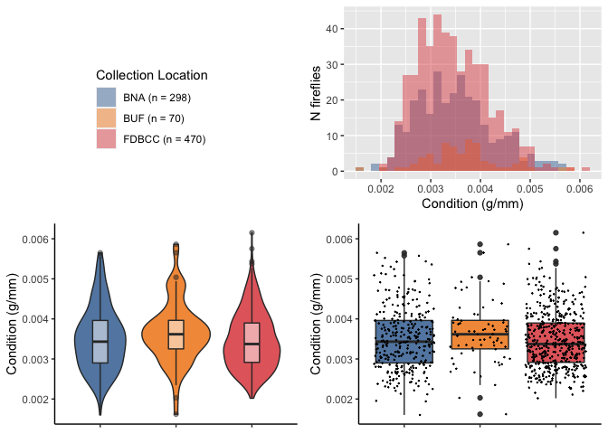

```r
#generate labels for sites that include sample size
site_labels = c(paste("BNA", " (n = ", t$N[1], ")", sep=""),
                paste0("BUF", " (n = ", t$N[2], ")"),
                paste0("FDBCC",  " (n = ", t$N[3], ")"))

#generate text placeholder
a <- ggplot(Adult_Final, aes(x=Condition, fill=Location)) +
  geom_histogram(alpha= 0.5, position="identity") +
  scale_fill_manual(name = "Collection Location", labels = site_labels, values = site_colors)

legend.a <- cowplot::get_legend(a)

#generate histogram
b <- ggplot(Adult_Final, aes(x=Condition, fill=Location)) +
  geom_histogram(alpha= 0.5, position="identity") +
  xlab("Condition (g/mm)") +
  ylab("N fireflies") +
  theme(plot.title = element_text(hjust = 0.5), legend.position = "none") +
  scale_fill_manual(name = "Location", labels = site_labels, values = site_colors)

#generate violin plot
c <- ggplot(Adult_Final, aes(x=Location, y=Condition, fill=Location)) +
  geom_violin(alpha = 0.9) +
  theme_classic() +
  ylab("Condition (g/mm)") +
  theme(plot.title = element_text(hjust = 0.5), legend.position = "none", axis.text.x=element_blank(), axis.title.x=element_blank()) +
  geom_boxplot(width=0.2, alpha= 0.5, fill = "white") +
  scale_fill_manual(values = site_colors)

#generate boxplot
d <- ggplot(Adult_Final, aes(x=Location, y=Condition, fill=Location)) +
  geom_boxplot(alpha = 0.9) +
  geom_jitter(size = 0.1)+
  theme_classic() +
  ylab("Condition (g/mm)") +
  theme(plot.title = element_text(hjust = 0.5), legend.position = "none", axis.text.x=element_blank(), axis.title.x=element_blank()) +
  scale_fill_manual(values = site_colors)

grid.arrange(legend.a,b,c,d, nrow=2)
```

### Q3. …by seasonday

- Data summary:

```r
#generate tibble
t <- Adult_Final %>%
  group_by(Location, SeasonDay) %>%
  summarise(N=n(), mean_length=round(mean(Condition),6), SD = round(sd(Condition),6)) %>%
  arrange(SeasonDay)

#make table nice in kable
kbl(t, col.names = c("Location", "Season Day", "n", "Mean condition (g/mm)", "SD"), align = "lcccc") %>%
  kable_classic(full_width = F, html_font = "Cambria")
```

| Location | Season Day | n | Mean condition (g/mm) | SD |
| --- | --- | --- | --- | --- |
| USA: Montour Co, Bucknell Natural Area | 9 | 92 | 0.003506 | 0.000797 |
| USA: Union Co, Bucknell Farm | 13 | 47 | 0.003692 | 0.000852 |
| USA: Montour Co, Bucknell Natural Area | 15 | 120 | 0.003541 | 0.000818 |
| USA: Union Co, Bucknell Ropes Course | 17 | 231 | 0.003552 | 0.000730 |
| USA: Montour Co, Bucknell Natural Area | 22 | 86 | 0.003450 | 0.000725 |
| USA: Union Co, Bucknell Ropes Course | 23 | 95 | 0.003459 | 0.000714 |
| USA: Union Co, Bucknell Farm | 30 | 23 | 0.003564 | 0.000568 |
| USA: Union Co, Bucknell Ropes Course | 31 | 90 | 0.003247 | 0.000614 |
| USA: Union Co, Bucknell Ropes Course | 36 | 54 | 0.003421 | 0.000664 |

- Raw data, three different ways:

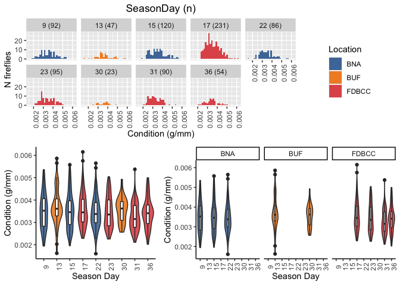

```r
#generate labels for seasondays that include sample size
t$SeasonDayLabel = paste(t$SeasonDay, " (", t$N, ")", sep ="")

seasonday_label <- c(
  '9' = t$SeasonDayLabel[1],
  '13' = t$SeasonDayLabel[2],
  '15' = t$SeasonDayLabel[3],
  '17' = t$SeasonDayLabel[4],
  '22' = t$SeasonDayLabel[5],
  '23' = t$SeasonDayLabel[6],
  '30' = t$SeasonDayLabel[7],
  '31' = t$SeasonDayLabel[8],
  '36' = t$SeasonDayLabel[9]
  )

#generate legend
e <- ggplot(Adult_Final, aes(x=Condition, fill=Location)) +
  geom_histogram() +
  xlab("Condition (g/mm)") +
  ylab("N fireflies") +
  theme(plot.title = element_text(hjust = 0.5)) +
  facet_wrap(~SeasonDay, labeller = as_labeller(seasonday_label)) +
  scale_fill_manual(name = "Location", labels = c("BNA", "BUF", "FDBCC"), values = c("#4E79A7", "#F28E2B", "#E15759"))

legend.e <- cowplot::get_legend(e)

#generate histogram
f <- ggplot(Adult_Final, aes(x=Condition, fill=Location)) +
  geom_histogram() +
  xlab("Condition (g/mm)") +
  ylab("N fireflies") +
  ggtitle("SeasonDay (n)") +
  theme(plot.title = element_text(hjust = 0.5), legend.position = "none", axis.text.x = element_text(angle = 90)) +
  facet_wrap(~SeasonDay, labeller = as_labeller(seasonday_label), ncol=5) +
  scale_fill_manual(name = "Location", labels = c("BNA", "BUF", "FDBCC"), values = c("#4E79A7", "#F28E2B", "#E15759"))

#generate violin plot by seasonday
g <- ggplot(Adult_Final, aes(x=as.factor(SeasonDay), y=Condition, fill = Location)) +
  geom_violin(alpha = 0.9) +
  theme_classic() +
  ylab("Condition (g/mm)") +
  xlab("Season Day") +
  theme(plot.title = element_text(hjust = 0.5), axis.text.x = element_text(angle = 90), legend.position = "none") +
  geom_boxplot(width=0.2, fill = "white") +
  scale_fill_manual(name = "Location", labels = c("BNA", "BUF", "FDBCC"), values = c("#4E79A7", "#F28E2B", "#E15759"))

#generate violin plot by site
h <- ggplot(Adult_Final, aes(x=as.factor(SeasonDay), y=Condition, fill = Location)) +
  geom_violin(alpha = 0.9) +
  theme_classic() +
  ylab("Condition (g/mm)") +
  xlab("Season Day") +
  theme(plot.title = element_text(hjust = 0.5), legend.position = "none", axis.text.x = element_text(angle = 90)) +
  facet_wrap(~Location, labeller = labeller(Location =
    c("USA: Montour Co, Bucknell Natural Area" = "BNA",
      "USA: Union Co, Bucknell Farm" = "BUF",
      "USA: Union Co, Bucknell Ropes Course" = "FDBCC"))) +
  geom_boxplot(width=0.2, fill = "white") +
  scale_fill_manual(values = c("#4E79A7", "#F28E2B", "#E15759"))

lay1 <- rbind(c(2,2,2,1))
lay2 <- rbind(c(1,1,2,2,2))

g1 <- arrangeGrob(legend.e, f, layout_matrix = lay1)
g2 <- arrangeGrob(g,h, layout_matrix = lay2)

grid.arrange(g1, g2, nrow=2)
```

### Q4. Are the distributions within each Location * SeasonDay normal?

Testing the *raw data:*

- **Q-Q plot** for the raw data (left) and **Shapiro test** (bottom right)

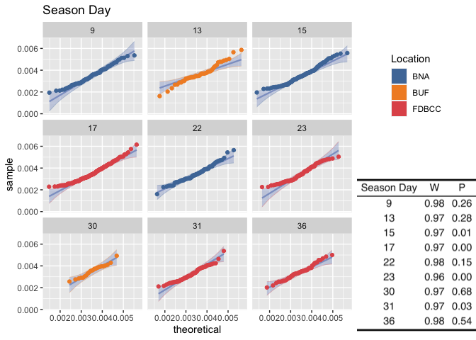

```r
#qq plots to assess normality
q <- ggplot(Adult_Final, aes(sample=Condition, color=Location)) +
  stat_qq_band(bandType = "pointwise", fill = "#8DA0CB", alpha = 0.4) +
  stat_qq_line(color = "#8DA0CB") +
  stat_qq_point() +
  ggtitle("Season Day") +
  facet_wrap(~SeasonDay) +
  scale_color_manual(name = "Location", labels = c("BNA", "BUF", "FDBCC"), values = c("#4E79A7", "#F28E2B", "#E15759")) +
  theme(legend.position = "none")

#statistically test
shapiro.table <- NULL
for (day in levels(factor(Adult_Final$SeasonDay))){
  #subset table
  table.sub <- Adult_Final[Adult_Final$SeasonDay == day,]
  test.result <- (shapiro.test(table.sub$Condition))
  info <- data.frame(SeasonDay = day, W = round(test.result[1]$statistic, 2), p = round(test.result[2]$p.value, 2))
  shapiro.table <- rbind(shapiro.table, info)
}

#create kable filename
kable_filename = paste("Condition_shapiro", ".png", sep="")

#generate nice table with kable
kbl(shapiro.table, row.names = FALSE, col.names = c("Season Day", "W", "P"), align = "ccc")  %>%
  kable_classic(full_width = F, html_font = "Cambria") %>%
  save_kable(file = kable_filename, bs_theme = "cerulean", zoom = 7)

#make big plot with table
#read in kable table as image
r <- ggdraw() +
  draw_image(kable_filename)

#stack the legend on top of the table
g3 <- arrangeGrob(legend.e, r, nrow =2)

#make the column width layout
shapiro_layout <- rbind(c(1,1,1,2))

#plot the graph next to the legend and table
grid.arrange(q, g3, nrow = 1,  layout_matrix = shapiro_layout)
```

**Conclusions:**

- *p* < 0.05 for conditions distributions from:
  - Day 15
  - Day 17
  - Day 23
  - Day 31

*4/9 collection days are not normally distributed, but all of these days have sample size greater than 30, meaning parametric stats should be fine. Proceed with using un-transformed condition in downstream analysis.*

### Q6. Do seasonday and location predict condition?

- Summary of effects:

```r
Condition<-lm(Condition~SeasonDay*Location, data=Adult_Final)
summary(Condition)
```

```
##
## Call:
## lm(formula = Condition ~ SeasonDay * Location, data = Adult_Final)
##
## Residuals:
##        Min         1Q     Median         3Q        Max
## -2.072e-03 -5.591e-04 -6.403e-05  4.587e-04  2.610e-03
##
## Coefficients:
##                                                          Estimate Std. Error
## (Intercept)                                             3.571e-03  1.358e-04
## SeasonDay                                              -4.468e-06  8.502e-06
## LocationUSA: Union Co, Bucknell Farm                    2.192e-04  2.613e-04
## LocationUSA: Union Co, Bucknell Ropes Course            1.946e-04  1.791e-04
## SeasonDay:LocationUSA: Union Co, Bucknell Farm         -3.094e-06  1.393e-05
## SeasonDay:LocationUSA: Union Co, Bucknell Ropes Course -8.798e-06  9.783e-06
##                                                        t value Pr(>|t|)
## (Intercept)                                             26.290   <2e-16 ***
## SeasonDay                                               -0.526    0.599
## LocationUSA: Union Co, Bucknell Farm                     0.839    0.402
## LocationUSA: Union Co, Bucknell Ropes Course             1.086    0.278
## SeasonDay:LocationUSA: Union Co, Bucknell Farm          -0.222    0.824
## SeasonDay:LocationUSA: Union Co, Bucknell Ropes Course  -0.899    0.369
## ---
## Signif. codes:  0 '***' 0.001 '**' 0.01 '*' 0.05 '.' 0.1 ' ' 1
##
## Residual standard error: 0.0007372 on 832 degrees of freedom
## Multiple R-squared:  0.01473,    Adjusted R-squared:  0.008813
## F-statistic: 2.488 on 5 and 832 DF,  p-value: 0.03003
```

- ANOVA(model) results:

```r
kbl(anova(Condition), digits = 3)  %>%
  kable_classic(full_width = F, html_font = "Cambria")
```

|  | Df | Sum Sq | Mean Sq | F value | Pr(>F) |
| --- | --- | --- | --- | --- | --- |
| SeasonDay | 1 | 0 | 0 | 8.119 | 0.004 |
| Location | 2 | 0 | 0 | 1.712 | 0.181 |
| SeasonDay:Location | 2 | 0 | 0 | 0.450 | 0.638 |
| Residuals | 832 | 0 | 0 | NA | NA |

### Plot

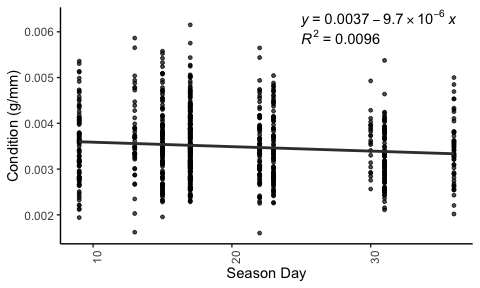

```r
#plot with all locations over the season
p_condition_by_season_day <- ggplot(Adult_Final, aes(x=as.numeric(SeasonDay), y=Condition)) +
  geom_point(size = 1, alpha = 0.7) +
  theme_classic() +
  ylab("Condition (g/mm)") +
  xlab("Season Day") +
  theme(plot.title = element_text(hjust = 0.5), axis.text.x = element_text(angle = 90), legend.position = "none") +
  geom_smooth(method = "lm", se=FALSE, color = "gray23") +
  stat_regline_equation(label.x = c(25), label.y = 0.0063, aes(label = ..eq.label..)) +
  stat_regline_equation(label.x = c(25), label.y = 0.0059, aes(label = ..rr.label..))

p_condition_by_season_day
```

## Step 4: Exploring linearity for survival analysis

Using the subset of the data of only UNINFECTED fireflies (either uninjected or injected with sterile PBS solution), we are exploring whether we need to transform any of our explanatory variables, or convert them to a different variable type (ordered factor vs categorical vs quantitative).

There are 223 fireflies in the UNINFECTED dataset.

Procedure: Assign individual fireflies to bins based on the explanatory variable using the whole dataset, not just uninfected fireflies. Want bins to be equidistant across the range of values of the explanatory variable. When run the model on just the uninfected subset, if the beta values are linear, then the explanatory variable can be considered quantitative in survival analysis.

### **Condition**

#### Q. Can **Condition** be quantitative or do we need to stratify the analysis?

- Summary:
  - **Condition** binned into **8 increments**
  - Seems good sample size for number of individuals in each bin, though the top and bottom bins are poorly supported (few fireflies)
  - CONCLUSION: **Condition** has a generally linear relationship, use as-is
- Analysis:
  - Checking bins for sample size

```r
#for Condition
Adult_Final$ConditionBins <- as.numeric(cut(Adult_Final$Condition, 8))
Adult_Final$ConditionBinsF<-as.factor(Adult_Final$ConditionBins)

#Subset the data to only include uninfected controls
Adult_Uninfected<-subset(Adult_Final, DoseBacteriaNumber=="0")

t <- t(table(Adult_Uninfected$ConditionBins))
row.names(t) <- "n"

kbl(t) %>%
  kable_classic(full_width = F, html_font = "Cambria", position = "center") %>%
  add_header_above(c(" ", "Bins"= 8))
```

|  | Bins 1 | Bins 2 | Bins 3 | Bins 4 | Bins 5 | Bins 6 | Bins 7 | Bins 8 |
| --- | --- | --- | --- | --- | --- | --- | --- | --- |
| n | 2 | 29 | 68 | 75 | 30 | 11 | 6 | 2 |

- Checking coefficients for linearity:

```r
modelCond<-coxph(Surv(Days_post_infection,Status)~ConditionBinsF,data=Adult_Uninfected)
summary(modelCond)
```

```
## Call:
## coxph(formula = Surv(Days_post_infection, Status) ~ ConditionBinsF,
##     data = Adult_Uninfected)
##
##   n= 223, number of events= 182
##
##                     coef exp(coef) se(coef)      z Pr(>|z|)
## ConditionBinsF2 -0.60247   0.54746  1.02714 -0.587   0.5575
## ConditionBinsF3 -0.70458   0.49431  1.01426 -0.695   0.4873
## ConditionBinsF4 -1.39611   0.24756  1.01756 -1.372   0.1701
## ConditionBinsF5 -1.66774   0.18867  1.03038 -1.619   0.1055
## ConditionBinsF6 -2.40944   0.08987  1.06703 -2.258   0.0239 *
## ConditionBinsF7 -1.16527   0.31184  1.08721 -1.072   0.2838
## ConditionBinsF8 -2.91551   0.05418  1.24445 -2.343   0.0191 *
## ---
## Signif. codes:  0 '***' 0.001 '**' 0.01 '*' 0.05 '.' 0.1 ' ' 1
##
##                 exp(coef) exp(-coef) lower .95 upper .95
## ConditionBinsF2   0.54746      1.827  0.073122    4.0988
## ConditionBinsF3   0.49431      2.023  0.067712    3.6086
## ConditionBinsF4   0.24756      4.039  0.033692    1.8190
## ConditionBinsF5   0.18867      5.300  0.025041    1.4216
## ConditionBinsF6   0.08987     11.128  0.011100    0.7275
## ConditionBinsF7   0.31184      3.207  0.037025    2.6264
## ConditionBinsF8   0.05418     18.458  0.004726    0.6210
##
## Concordance= 0.637  (se = 0.026 )
## Likelihood ratio test= 45.13  on 7 df,   p=1e-07
## Wald test            = 40.19  on 7 df,   p=1e-06
## Score (logrank) test = 43.78  on 7 df,   p=2e-07
```

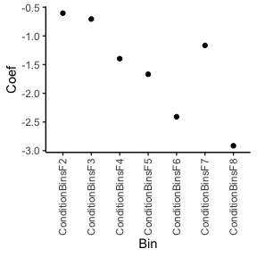

```r
df <- tibble(Bin = names(modelCond$coefficients), Coef = (modelCond$coefficients))

ggplot(df,aes(x=Bin, y=Coef)) +
  geom_point() +
  theme_classic() +
  theme(axis.text.x = element_text(angle = 90, vjust = 0.5, hjust=1))
```

### **SeasonDay**

#### Q. Can **SeasonDay** be considered linear?

+Summary: + **Season Day** binned into **5 increments** + The fourth bin poorly supported (low sample size) + The intervals between bins are pretty good (0.1,0.4,0.45,0.5) + CONCLUSION: Generally looks linear! Use as is.

- Analysis
  - Checking bins for sample size

```r
#Season Day with 5 increments, fourth bin poorly supported, intervals between bins (0.1,0.4,0.45,0.5) - doesn't look great. Do we need to take other variables into account first? Then would it act linearly?

#set up bins for SeasonDay
Adult_Final$SeasonDayBins <- as.numeric(cut(Adult_Final$SeasonDay, 5))
#table(Adult_Final$SeasonDayBins) #how many in each category
Adult_Final$SeasonDayBinsF<-as.factor(Adult_Final$SeasonDayBins)

#Subset the data to only include uninfected controls
Adult_Uninfected<-subset(Adult_Final, DoseBacteriaNumber=="0")
#nrow(Adult_Uninfected)

t <- t(table(Adult_Uninfected$SeasonDayBinsF))
row.names(t) <- "n"

kbl(t) %>%
  kable_classic(full_width = F, html_font = "Cambria", position = "center") %>%
  add_header_above(c(" ", "Bins"= 5))
```

|  | Bins 1 | Bins 2 | Bins 3 | Bins 4 | Bins 5 |
| --- | --- | --- | --- | --- | --- |
| n | 44 | 74 | 51 | 6 | 48 |

- Checking coefficients for linearity:

```r
modelSD<-coxph(Surv(Days_post_infection,Status)~SeasonDayBinsF,data=Adult_Uninfected)
summary(modelSD)
```

```
## Call:
## coxph(formula = Surv(Days_post_infection, Status) ~ SeasonDayBinsF,
##     data = Adult_Uninfected)
##
##   n= 223, number of events= 182
##
##                    coef exp(coef) se(coef)     z Pr(>|z|)
## SeasonDayBinsF2 0.06884   1.07126  0.19227 0.358  0.72033
## SeasonDayBinsF3 0.54712   1.72828  0.20696 2.644  0.00820 **
## SeasonDayBinsF4 0.95171   2.59013  0.43999 2.163  0.03054 *
## SeasonDayBinsF5 1.48494   4.41472  0.50126 2.962  0.00305 **
## ---
## Signif. codes:  0 '***' 0.001 '**' 0.01 '*' 0.05 '.' 0.1 ' ' 1
##
##                 exp(coef) exp(-coef) lower .95 upper .95
## SeasonDayBinsF2     1.071     0.9335    0.7349     1.562
## SeasonDayBinsF3     1.728     0.5786    1.1520     2.593
## SeasonDayBinsF4     2.590     0.3861    1.0935     6.135
## SeasonDayBinsF5     4.415     0.2265    1.6528    11.792
##
## Concordance= 0.607  (se = 0.022 )
## Likelihood ratio test= 16.71  on 4 df,   p=0.002
## Wald test            = 18.21  on 4 df,   p=0.001
## Score (logrank) test = 19.43  on 4 df,   p=6e-04
```

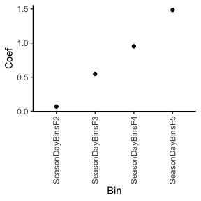

```r
df <- tibble(Bin = names(modelSD$coefficients), Coef = (modelSD$coefficients))

ggplot(df,aes(x=Bin, y=Coef)) +
  geom_point() +
  theme_classic() +
  theme(axis.text.x = element_text(angle = 90, vjust = 0.5, hjust=1))
```